# Programming Tools & Techniques in Data Management

A. Malinish

2020-11-26

### Required Packages

```r
library(psych)
```

## Normal Distribution Density Plot

In this section, a standard normal distribution is generated and displayed as a density plot.

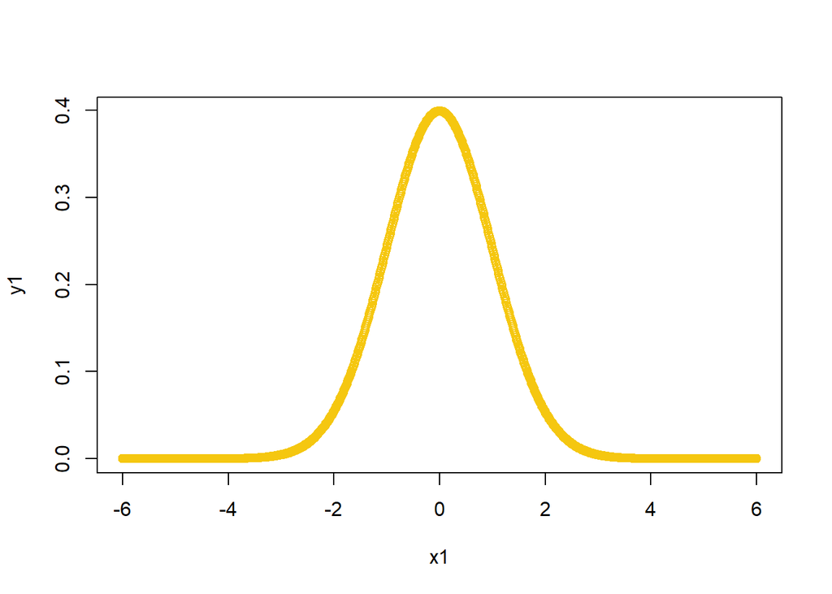

```r
x1 = seq(from = -6, to = 6, by = 0.01)
y1 = dnorm(x1)
plot(x1, y1, col = 7)
```

## Boxplot

```r
data(airquality)
str(airquality)
```

```
## 'data.frame':    153 obs. of  6 variables:
##  $ Ozone  : int  41 36 12 18 NA 28 23 19 8 NA ...
##  $ Solar.R: int  190 118 149 313 NA NA 299 99 19 194 ...
##  $ Wind   : num  7.4 8 12.6 11.5 14.3 14.9 8.6 13.8 20.1 8.6 ...
##  $ Temp   : int  67 72 74 62 56 66 65 59 61 69 ...
##  $ Month  : int  5 5 5 5 5 5 5 5 5 5 ...
##  $ Day    : int  1 2 3 4 5 6 7 8 9 10 ...
```

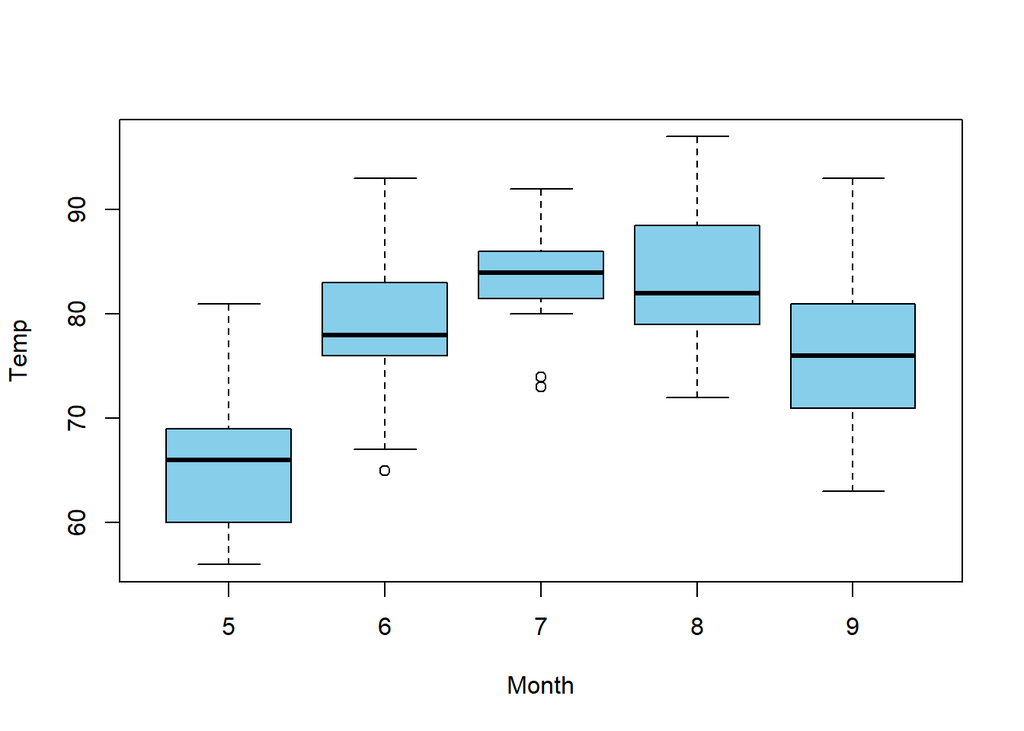

```r
airquality$Month <- as.factor(airquality$Month)
attach(airquality)
boxplot(Temp ~ Month, col = "skyblue")
```

## Creating and Storing Functions

A new function is created and stored as **FunData** in this step. **FunData** is used to create and specify values for new variables and return the variables as a dataframe. **FunData** is then used to created the dataframe, *df*.

```r
FunData <- function(){
  ID = 1:20
  Gender = rep(c("M","F"),10)
  Age = c(19,20,19,20,21,22,23,19,18,24,21,22,19,20,21,23,21,22,20,18)
  Weight = rnorm(20, mean = 130, sd = 5)
  Height = rnorm(20, mean = 70, sd = 4)
  return(data.frame(ID,Gender,Age,Weight,Height))
}

df <- FunData()
df
```

```
##    ID Gender Age   Weight   Height
## 1   1      M  19 126.7168 69.71760
## 2   2      F  20 126.7665 70.05590
## 3   3      M  19 135.7494 68.40863
## 4   4      F  20 129.6855 77.46861
## 5   5      M  21 135.3122 77.94269
## 6   6      F  22 129.0212 73.55892
## 7   7      M  23 133.6823 78.11997
## 8   8      F  19 138.8062 71.37091
## 9   9      M  18 129.5995 77.43509
## 10 10      F  24 132.3817 80.22663
## 11 11      M  21 137.9415 67.38812
## 12 12      F  22 142.1391 73.23627
## 13 13      M  19 131.0616 62.81915
## 14 14      F  20 138.0488 68.12412
## 15 15      M  21 135.8697 70.98211
## 16 16      F  23 127.9851 66.23406
## 17 17      M  21 134.0247 69.78343
## 18 18      F  22 133.0081 77.59529
## 19 19      M  20 132.6852 70.46548
## 20 20      F  18 137.9963 66.51811
```

## Computing Mean Values

Mean values for **Age**, **Weight**, and **Height** by **Gender** from the dataframe *df* are calculated in this step using the tapply() function. Mean values are as follows:

```r
attach(df)
tapply(Age, Gender, mean)
```

```
##    F    M
## 21.0 20.2
```

```r
tapply(Weight, Gender, mean)
```

```
##        F        M
## 133.5839 133.2643
```

```r
tapply(Height, Gender, mean)
```

```
##        F        M
## 72.43888 71.30623
```

## Creating Calculated Variable

The dataset, *bodyfat* (Penrose, 1985), was imported into R and stored as *bodyfat* for this section. The structure of *bodyfat* (Penrose, 1985) includes 252 observations comprised of 15 variables. An additional variable, **bmi**, was created by performing manual calculations for **bmi** and storing them as a vector. The cbind() function was then used to add the vector of **bmi**’s to *bodyfat*. A summary of the variables shows that **bmi** has a mean value of 25.94.

```r
bodyfat <- read.csv("bodyfat.csv")
str(bodyfat)
```

```
## 'data.frame':    252 obs. of  15 variables:
##  $ density: num  1.07 1.09 1.04 1.08 1.03 ...
##  $ bodyfat: num  12.3 6.1 25.3 10.4 28.7 20.9 19.2 12.4 4.1 11.7 ...
##  $ age    : int  23 22 22 26 24 24 26 25 25 23 ...
##  $ weight : num  154 173 154 185 184 ...
##  $ height : num  67.8 72.2 66.2 72.2 71.2 ...
##  $ neck   : num  36.2 38.5 34 37.4 34.4 39 36.4 37.8 38.1 42.1 ...
##  $ chest  : num  93.1 93.6 95.8 101.8 97.3 ...
##  $ abdomen: num  85.2 83 87.9 86.4 100 94.4 90.7 88.5 82.5 88.6 ...
##  $ hip    : num  94.5 98.7 99.2 101.2 101.9 ...
##  $ thigh  : num  59 58.7 59.6 60.1 63.2 66 58.4 60 62.9 63.1 ...
##  $ knee   : num  37.3 37.3 38.9 37.3 42.2 42 38.3 39.4 38.3 41.7 ...
##  $ ankle  : num  21.9 23.4 24 22.8 24 25.6 22.9 23.2 23.8 25 ...
##  $ biceps : num  32 30.5 28.8 32.4 32.2 35.7 31.9 30.5 35.9 35.6 ...
##  $ forearm: num  27.4 28.9 25.2 29.4 27.7 30.6 27.8 29 31.1 30 ...
##  $ wrist  : num  17.1 18.2 16.6 18.2 17.7 18.8 17.7 18.8 18.2 19.2 ...
```

```r
bmi <- 703*bodyfat$weight/bodyfat$height^2
bodyfat <- cbind(bodyfat,bmi)

head(bodyfat)
```

```
##   density bodyfat age weight height neck chest abdomen   hip thigh knee ankle
## 1  1.0708    12.3  23 154.25  67.75 36.2  93.1    85.2  94.5  59.0 37.3  21.9
## 2  1.0853     6.1  22 173.25  72.25 38.5  93.6    83.0  98.7  58.7 37.3  23.4
## 3  1.0414    25.3  22 154.00  66.25 34.0  95.8    87.9  99.2  59.6 38.9  24.0
## 4  1.0751    10.4  26 184.75  72.25 37.4 101.8    86.4 101.2  60.1 37.3  22.8
## 5  1.0340    28.7  24 184.25  71.25 34.4  97.3   100.0 101.9  63.2 42.2  24.0
## 6  1.0502    20.9  24 210.25  74.75 39.0 104.5    94.4 107.8  66.0 42.0  25.6
##   biceps forearm wrist      bmi
## 1   32.0    27.4  17.1 23.62446
## 2   30.5    28.9  18.2 23.33205
## 3   28.8    25.2  16.6 24.66632
## 4   32.4    29.4  18.2 24.88078
## 5   32.2    27.7  17.7 25.51485
## 6   35.7    30.6  18.8 26.45263
```

```r
summary(bodyfat)
```

```
##     density         bodyfat           age            weight
##  Min.   :0.995   Min.   : 0.00   Min.   :22.00   Min.   :118.5
##  1st Qu.:1.041   1st Qu.:12.47   1st Qu.:35.75   1st Qu.:159.0
##  Median :1.055   Median :19.20   Median :43.00   Median :176.5
##  Mean   :1.056   Mean   :19.15   Mean   :44.88   Mean   :178.9
##  3rd Qu.:1.070   3rd Qu.:25.30   3rd Qu.:54.00   3rd Qu.:197.0
##  Max.   :1.109   Max.   :47.50   Max.   :81.00   Max.   :363.1
##      height           neck           chest           abdomen
##  Min.   :29.50   Min.   :31.10   Min.   : 79.30   Min.   : 69.40
##  1st Qu.:68.25   1st Qu.:36.40   1st Qu.: 94.35   1st Qu.: 84.58
##  Median :70.00   Median :38.00   Median : 99.65   Median : 90.95
##  Mean   :70.15   Mean   :37.99   Mean   :100.82   Mean   : 92.56
##  3rd Qu.:72.25   3rd Qu.:39.42   3rd Qu.:105.38   3rd Qu.: 99.33
##  Max.   :77.75   Max.   :51.20   Max.   :136.20   Max.   :148.10
##       hip            thigh            knee           ankle          biceps
##  Min.   : 85.0   Min.   :47.20   Min.   :33.00   Min.   :19.1   Min.   :24.80
##  1st Qu.: 95.5   1st Qu.:56.00   1st Qu.:36.98   1st Qu.:22.0   1st Qu.:30.20
##  Median : 99.3   Median :59.00   Median :38.50   Median :22.8   Median :32.05
##  Mean   : 99.9   Mean   :59.41   Mean   :38.59   Mean   :23.1   Mean   :32.27
##  3rd Qu.:103.5   3rd Qu.:62.35   3rd Qu.:39.92   3rd Qu.:24.0   3rd Qu.:34.33
##  Max.   :147.7   Max.   :87.30   Max.   :49.10   Max.   :33.9   Max.   :45.00
##     forearm          wrist            bmi
##  Min.   :21.00   Min.   :15.80   Min.   : 18.02
##  1st Qu.:27.30   1st Qu.:17.60   1st Qu.: 23.03
##  Median :28.70   Median :18.30   Median : 25.09
##  Mean   :28.66   Mean   :18.23   Mean   : 25.94
##  3rd Qu.:30.00   3rd Qu.:18.80   3rd Qu.: 27.33
##  Max.   :34.90   Max.   :21.40   Max.   :165.60
```

## Correlation Matrix

The correlation matrix of **density**, **bodyfat**, **weight**, **height**, and **bmi** indicates that the strongest correlation exists between **density** and **bodyfat** (Pearson correlation = -0.99). This Pearson correlation value represents a negative correlation, meaning that as one variable increases in value, the other variable decreases in value. Meanwhile, the strongest positive correlation exists between **bodyfat** and **weight** (Pearson correlation = 0.61). This type of correlation suggests that both variables increase and decrease with one another.

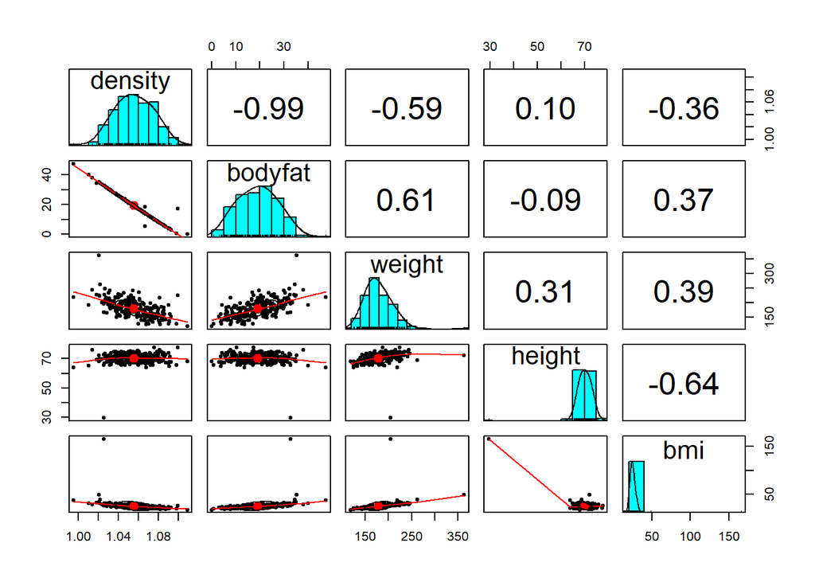

```r
pairs.panels(bodyfat[,c(1,2,4,5,16)])
```

## References

From “Generalized Body Composition Prediction Equation for Men Using Simple Measurement Techniques [Data set],” by Penrose, K., Nelson, A. and Fisher, A. (1985). *Medicine and Science in Sports and Exercise, 17*(189). http://dx.doi.org/10.1249/00005768-198504000-00037

Revelle, W. (2020). psych: Procedures for Psychological, Psychometric, and Personality Research. *Northwestern University*. https://CRAN.R-project.org/package=psych